# Donkey Games

Final Project

Stuart McColl

January 2021

# Introduction

The following report provides an exploratory analysis into the sales of video games. The data used for this report contains the global sales of games dating as far back as 1970 through to the present. Having such a vast range of games sales allows for a interesting look in to trends in top games across the years in order to identify what types of games, historically have performed well.

# The Data

### General Observations

**A brief glimpse at the data:**

| name | year_of_release | genre | publisher | na_sales | eu_sales | jp_sales | other_sales | global_sales | console | developer |
| --- | --- | --- | --- | --- | --- | --- | --- | --- | --- | --- |
| Wii Sports | 2006 | Sports | Nintendo | 41.36 | 28.96 | 3.77 | 8.45 | 82.53 | Wii | Nintendo |
| Super Mario Bros. | 1985 | Platform | Nintendo | 29.08 | 3.58 | 6.81 | 0.77 | 40.24 | NES | Unknown |
| Mario Kart Wii | 2008 | Racing | Nintendo | 15.68 | 12.76 | 3.79 | 3.29 | 35.52 | Wii | Nintendo |
| Wii Sports Resort | 2009 | Sports | Nintendo | 15.61 | 10.93 | 3.28 | 2.95 | 32.77 | Wii | Nintendo |
| Pokemon Red/Pokemon Blue | 1996 | Role-Playing | Nintendo | 11.27 | 8.89 | 10.22 | 1.00 | 31.37 | GB | Unknown |
| Tetris | 1989 | Puzzle | Nintendo | 23.20 | 2.26 | 4.22 | 0.58 | 30.26 | GB | Unknown |

The data is an amalgamation of 4 data sets, each with their own set of sales and useful information. The final data contains the most up to date sales figures for each game as of 2019.

# Games History

### 1970’s

| name | total_global_sales |
| --- | --- |
| Space Invaders | 2.53 |
| Adventure | 1.30 |
| Combat | 1.25 |
| Air-Sea Battle | 0.98 |
| Circus Atari | 0.46 |
| Maze Craze: A Game of Cops 'n Robbers | 0.45 |
| Super Breakout | 0.44 |
| TERA | 0.42 |
| Hangman | 0.38 |
| Slot Machine | 0.31 |

[output cut: 12 more lines]

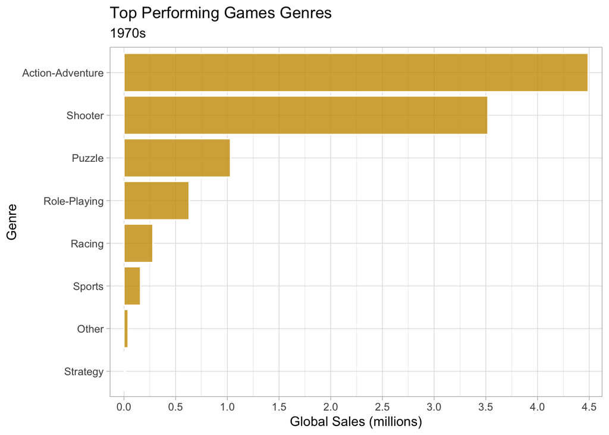

### 1980’s

| name | total_global_sales |
| --- | --- |
| Super Mario Bros. | 40.24 |
| Tetris | 35.84 |
| Duck Hunt | 28.31 |
| Super Mario Land | 18.14 |
| Super Mario Bros. 3 | 17.28 |
| Pac-Man | 7.81 |
| Super Mario Bros. 2 | 7.46 |
| The Legend of Zelda | 6.51 |
| Golf | 6.13 |
| Dr. Mario | 5.34 |

[output cut: 187 more lines]

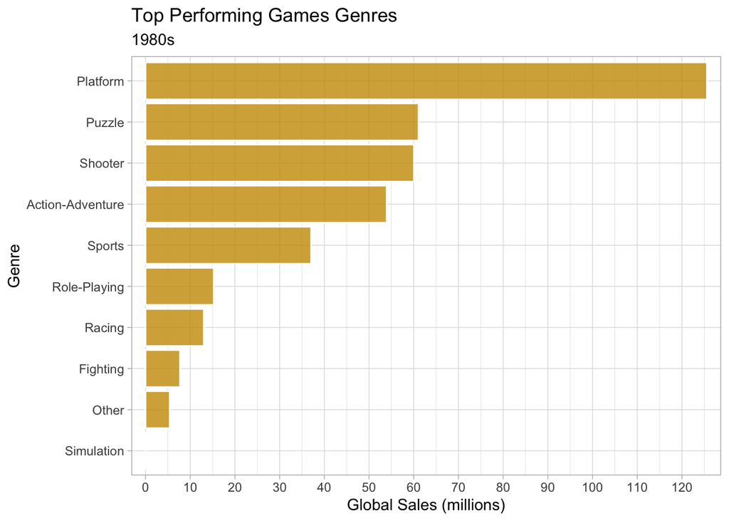

### 1990’s

| name | total_global_sales |
| --- | --- |
| Pokemon Red/Pokemon Blue | 31.37 |
| Pokemon Gold/Pokemon Silver | 23.10 |
| Super Mario World | 20.61 |
| Pokémon Yellow: Special Pikachu Edition | 14.64 |
| Super Mario 64 | 11.89 |
| Super Mario Land 2: 6 Golden Coins | 11.18 |
| Gran Turismo | 10.95 |
| Super Mario All-Stars | 10.55 |
| Mario Kart 64 | 9.87 |
| Final Fantasy VII | 9.72 |

[output cut: 1572 more lines]

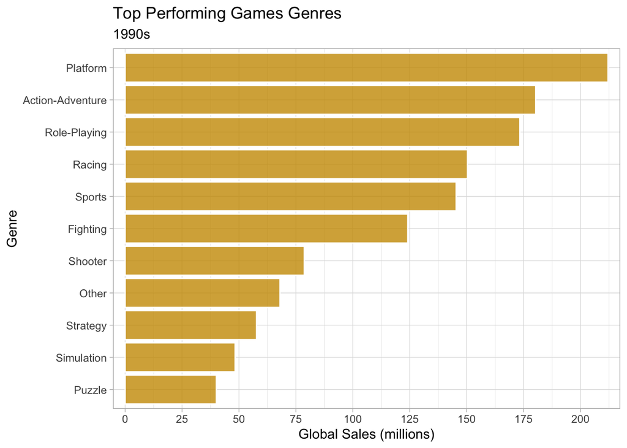

### 2000’s

| name | total_global_sales |
| --- | --- |
| Wii Sports | 82.53 |
| Mario Kart Wii | 35.52 |
| Wii Sports Resort | 32.77 |
| Call of Duty: Black Ops | 30.99 |
| New Super Mario Bros. | 29.80 |
| Wii Play | 28.92 |
| New Super Mario Bros. Wii | 28.32 |
| Call of Duty: Modern Warfare 2 | 25.02 |
| Nintendogs | 24.67 |
| Grand Theft Auto: San Andreas | 23.97 |

[output cut: 7960 more lines]

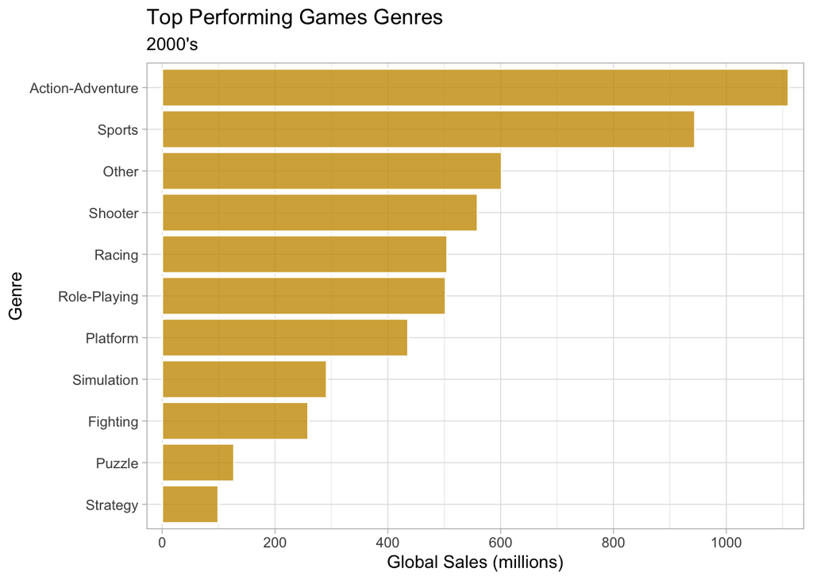

### 2010’s

| name | total_global_sales |
| --- | --- |
| Grand Theft Auto V | 65.46 |
| Minecraft | 33.19 |
| Call of Duty: Black Ops | 30.99 |
| Call of Duty: Modern Warfare 3 | 30.71 |
| Call of Duty: Black Ops II | 29.59 |
| Call of Duty: Ghosts | 28.80 |
| Call of Duty: Black Ops 3 | 26.72 |
| The Elder Scrolls V: Skyrim | 25.70 |
| Kinect Adventures! | 21.81 |
| Call of Duty: Advanced Warfare | 21.78 |

[output cut: 4837 more lines]

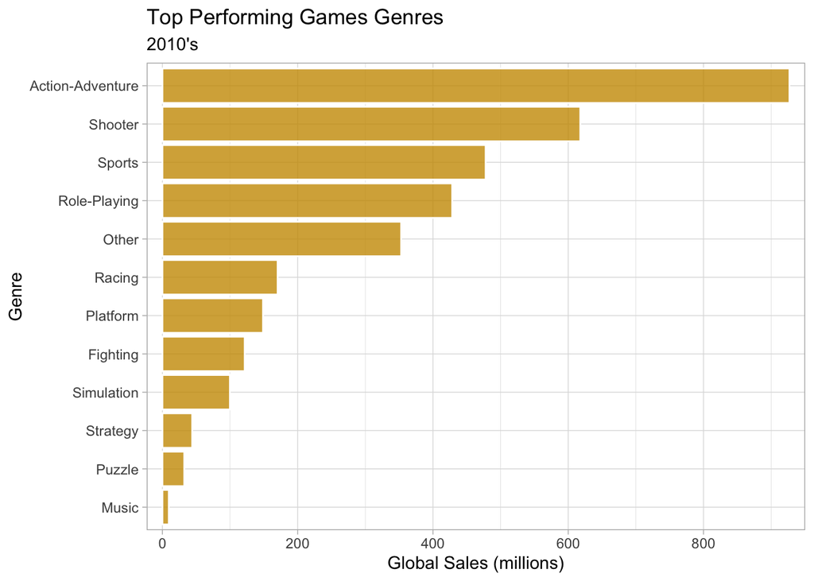

# Games Genres

### Action and Adventure Games

| name | total_global_sales |
| --- | --- |
| Grand Theft Auto V | 65.46 |
| Grand Theft Auto: San Andreas | 23.97 |
| Grand Theft Auto IV | 22.53 |
| Red Dead Redemption 2 | 19.71 |
| Grand Theft Auto: Vice City | 16.19 |
| FIFA Soccer 13 | 15.52 |
| LEGO Star Wars: The Complete Saga | 15.33 |
| Assassin's Creed IV: Black Flag | 13.71 |
| LEGO Batman: The Videogame | 13.55 |
| Grand Theft Auto III | 13.11 |

**Grand Theft Auto** clearly dominates the **Action-Adventure** category.

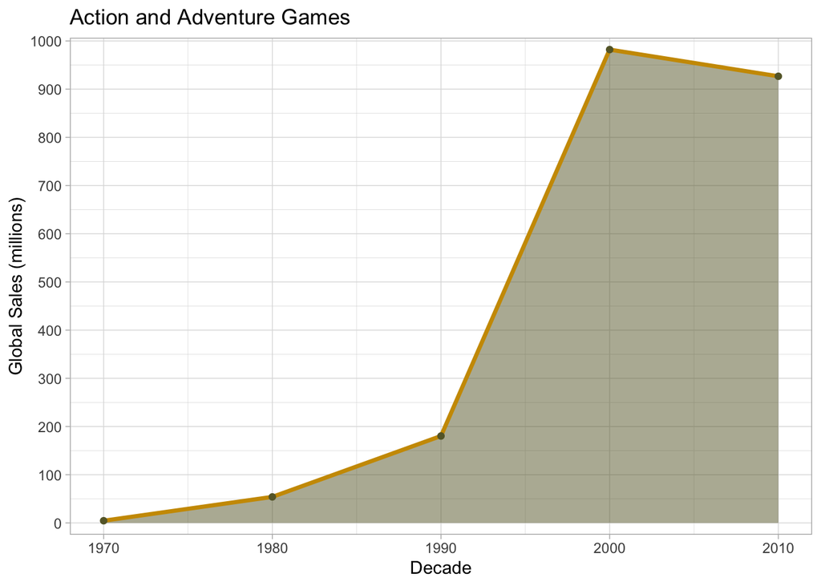

### Sports Games

| name | total_global_sales |
| --- | --- |
| Wii Sports | 82.53 |
| Wii Sports Resort | 32.77 |
| Wii Fit | 22.70 |
| Wii Fit Plus | 21.79 |
| FIFA 15 | 18.03 |
| FIFA 14 | 17.31 |
| FIFA 17 | 17.02 |
| FIFA 18 | 16.92 |
| FIFA 16 | 15.82 |
| FIFA 13 | 15.36 |

**Wii Sports** clearly wins this category. **FIFA** also highly ranked in this category.

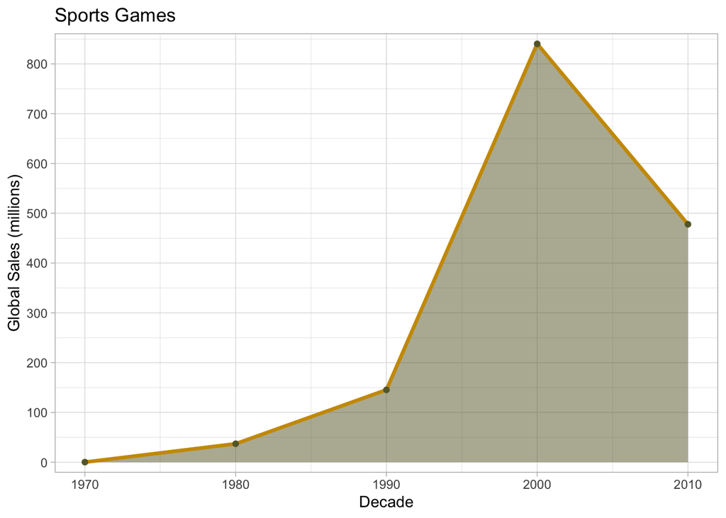

### Shooter Games

| name | total_global_sales |
| --- | --- |
| Call of Duty: Black Ops | 30.99 |
| Call of Duty: Modern Warfare 3 | 30.71 |
| Call of Duty: Black Ops II | 29.59 |
| Call of Duty: Ghosts | 28.80 |
| Duck Hunt | 28.31 |
| Call of Duty: Black Ops 3 | 26.72 |
| Call of Duty: Modern Warfare 2 | 25.02 |
| Call of Duty: Advanced Warfare | 21.78 |
| Call of Duty: WWII | 19.82 |
| Call of Duty 4: Modern Warfare | 18.33 |

**Call of Duty** tops the **shooter** games in this category.

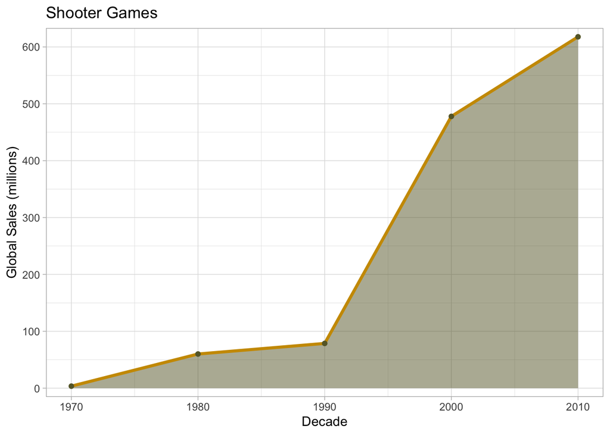

### Role Playing Games

| name | total_global_sales |
| --- | --- |
| Pokemon Red/Pokemon Blue | 31.37 |
| The Elder Scrolls V: Skyrim | 25.70 |
| Pokemon Gold/Pokemon Silver | 23.32 |
| Pokemon Diamond/Pokemon Pearl | 18.25 |
| Pokemon Ruby/Pokemon Sapphire | 15.85 |
| Pokemon Black/Pokemon White | 15.14 |
| Fallout 4 | 14.91 |
| Pokémon Yellow: Special Pikachu Edition | 14.64 |
| Pokemon X/Pokemon Y | 14.60 |
| Diablo III | 12.32 |

**Pokemon** are the clear winners from this category.

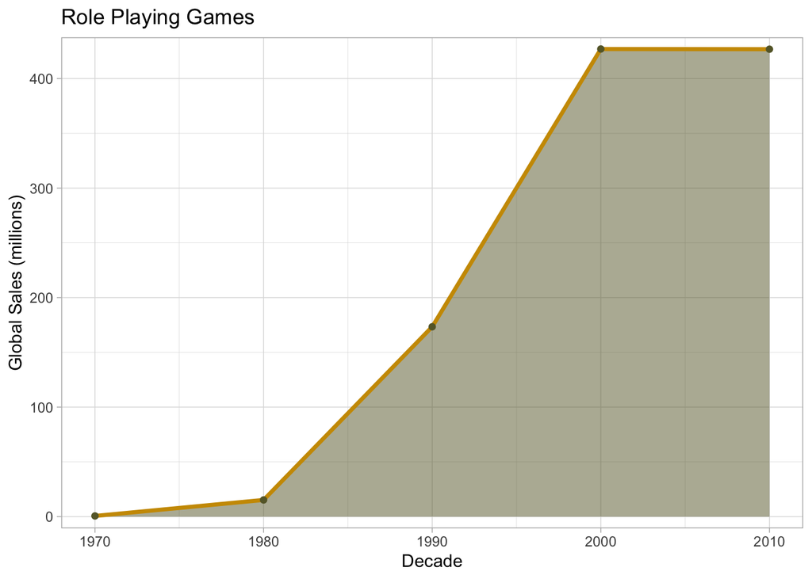

### Platform Games

| name | total_global_sales |
| --- | --- |
| Super Mario Bros. | 45.31 |
| New Super Mario Bros. | 29.80 |
| New Super Mario Bros. Wii | 28.32 |
| Super Mario World | 26.07 |
| Super Mario Bros. 3 | 22.48 |
| Super Mario 64 | 22.19 |
| Super Mario Land | 18.14 |
| Donkey Kong Country | 13.53 |
| Super Mario Galaxy | 11.35 |
| Super Mario 3D Land | 10.81 |

**Super Mario** clearly dominates the **platform** games category.

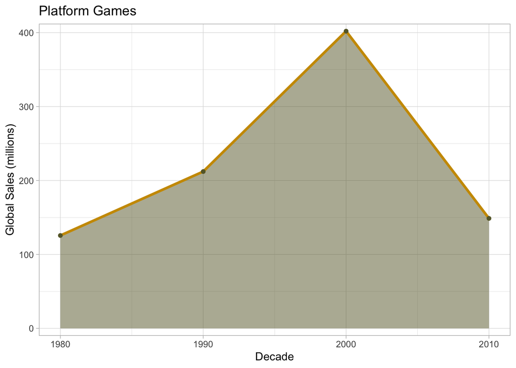

### Other Games

| name | total_global_sales |
| --- | --- |
| Minecraft | 33.19 |
| Wii Play | 28.92 |
| Kinect Adventures! | 21.81 |
| Brain Age: Train Your Brain in Minutes a Day | 20.15 |
| Guitar Hero III: Legends of Rock | 16.38 |
| Just Dance 3 | 12.79 |
| MineCraft | 11.76 |
| Guitar Hero: World Tour | 10.03 |
| Just Dance 2 | 9.44 |
| Just Dance 4 | 8.93 |

This is an interesting category as there is quite a mix of top games. **Minecraft** takes the top spot. **Just Dance** also performing well i nthis category.

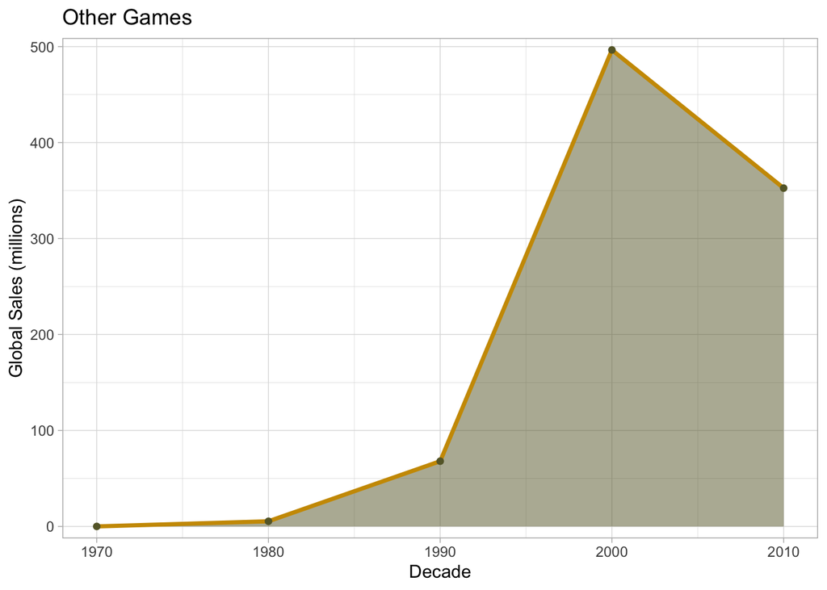

### Racing Games

| name | total_global_sales |
| --- | --- |
| Mario Kart Wii | 35.52 |
| Mario Kart DS | 23.21 |
| Gran Turismo 3: A-Spec | 14.98 |
| Mario Kart 7 | 12.66 |
| Need for Speed: Most Wanted | 12.12 |
| Gran Turismo 4 | 11.66 |
| Gran Turismo | 10.95 |
| Need for Speed Underground 2 | 10.95 |
| Gran Turismo 5 | 10.70 |
| Need for Speed Underground | 10.46 |

**Mario Kart** taking lead in this category. **Gran Turismo** also performing very well.

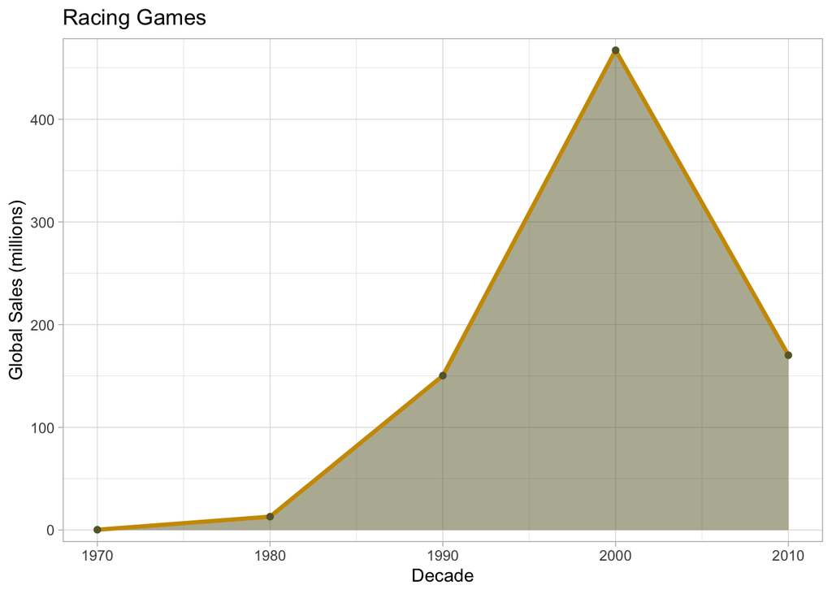

### Fighting Games

| name | total_global_sales |
| --- | --- |
| Super Smash Bros. Brawl | 12.84 |
| Super Smash Bros. for Wii U and 3DS | 12.42 |
| WWE SmackDown vs Raw 2008 | 7.39 |
| Street Fighter IV | 7.27 |
| Tekken 3 | 7.16 |
| Super Smash Bros. Melee | 7.07 |
| Street Fighter II: The World Warrior | 6.30 |
| Mortal Kombat | 6.05 |
| Tekken 2 | 5.74 |
| Mortal Kombat (2011) | 5.73 |

**Super Smash Bros. Brawl** taking first place in this category. Classic fighting games such as **Tekken**, **Mortal Kombat** and **Street Fighter** are very popular.

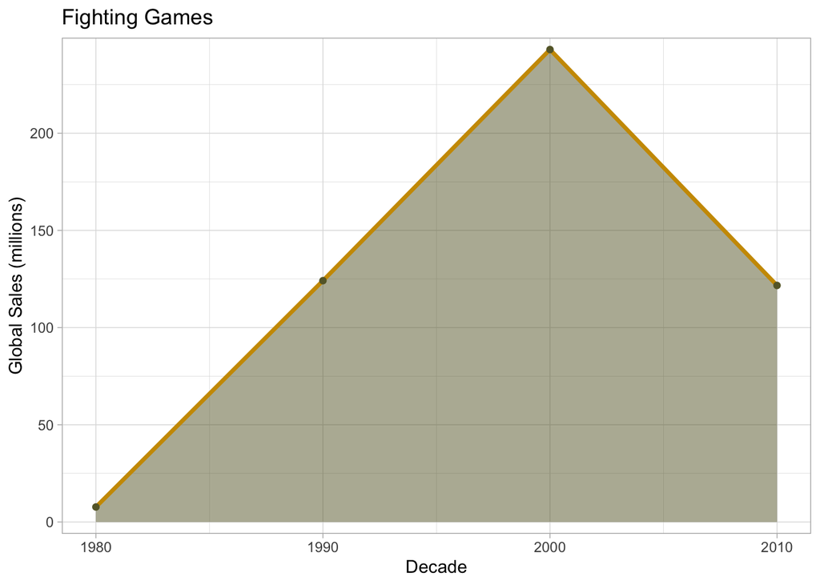

### Simulation Games

| name | total_global_sales |
| --- | --- |
| Nintendogs | 24.67 |
| The Sims 3 | 15.20 |
| Animal Crossing: Wild World | 12.13 |
| Animal Crossing: New Leaf | 9.16 |
| The Sims 4 | 6.22 |
| Cooking Mama | 5.66 |
| MySims | 5.34 |
| Tomodachi Life | 5.23 |
| Microsoft Flight Simulator | 5.12 |
| The Sims: Bustin' Out | 4.98 |

Interesting result from this category, **Nintendogs** is top in global sales. **The Sims** and **Animal Crossing** also performing well.

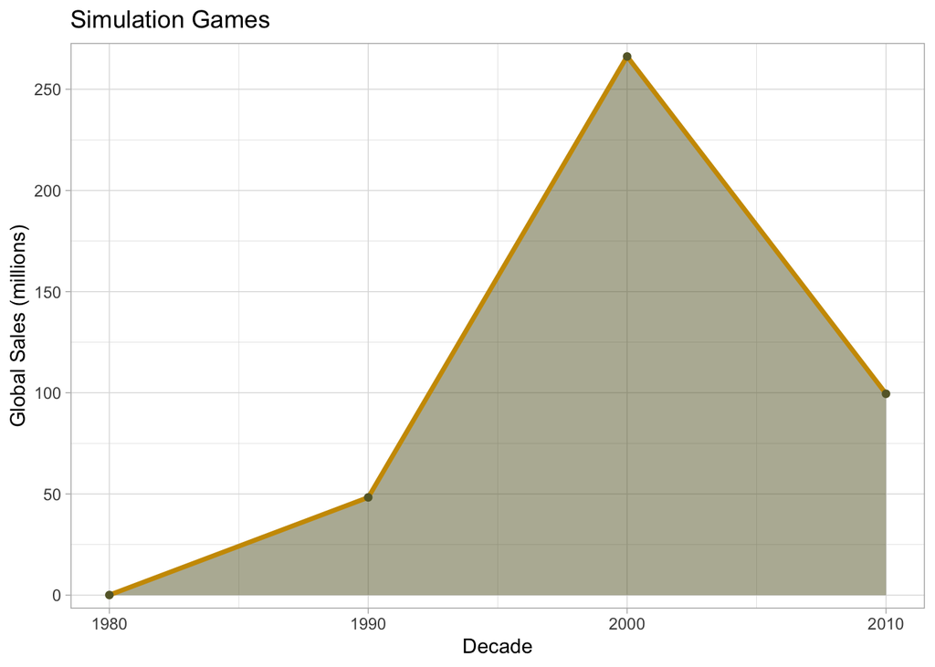

### Puzzle Games

| name | total_global_sales |
| --- | --- |
| Tetris | 35.84 |
| Brain Age 2: More Training in Minutes a Day | 15.29 |
| Dr. Mario | 10.19 |
| Pac-Man | 9.03 |
| Professor Layton and the Curious Village | 5.19 |
| Tetris Worlds | 4.01 |
| Professor Layton and the Diabolical Box | 3.94 |
| Professor Layton and the Unwound Future | 3.26 |
| Pac-Man Collection | 2.94 |
| WarioWare: Smooth Moves | 2.89 |

**Tetris** is the top classic puzzle game. **Brain Age** performed very well in this category.

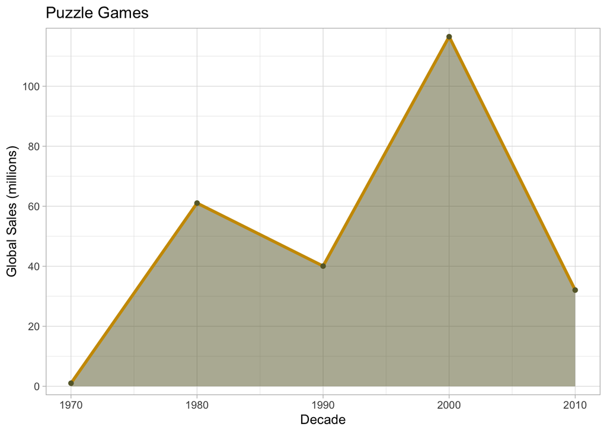

### Strategy Games

| name | total_global_sales |
| --- | --- |
| Pokemon Stadium | 5.45 |
| Warzone 2100 | 5.01 |
| StarCraft II: Wings of Liberty | 4.84 |
| Warcraft II: Tides of Darkness | 4.21 |
| Pokémon Trading Card Game | 3.70 |
| Command & Conquer: Red Alert | 3.26 |
| Pokémon Stadium 2 | 2.73 |
| Sim Theme Park | 2.71 |
| Halo Wars | 2.67 |
| Mario + Rabbids: Kingdom Battle | 2.59 |

**Pokemon Stadium** is the top game in this category.

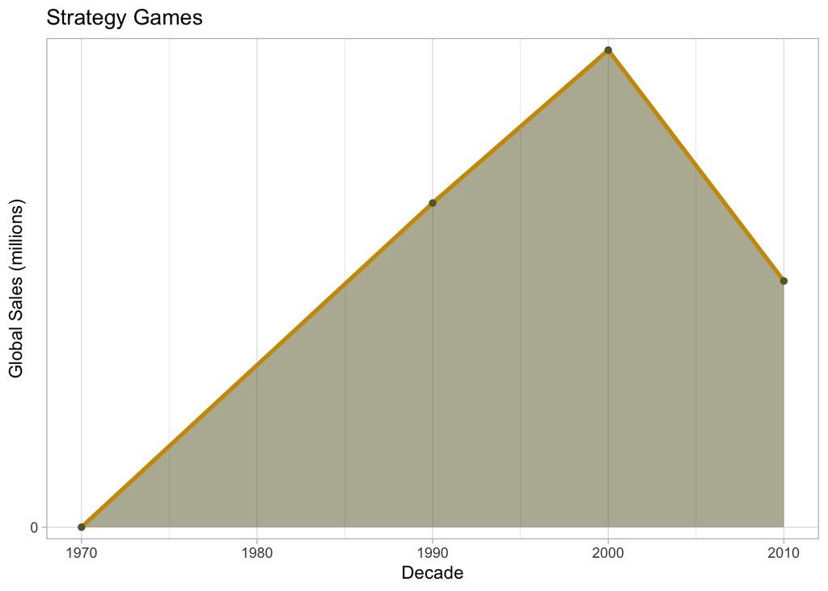

# Regional Sales

### All Regions

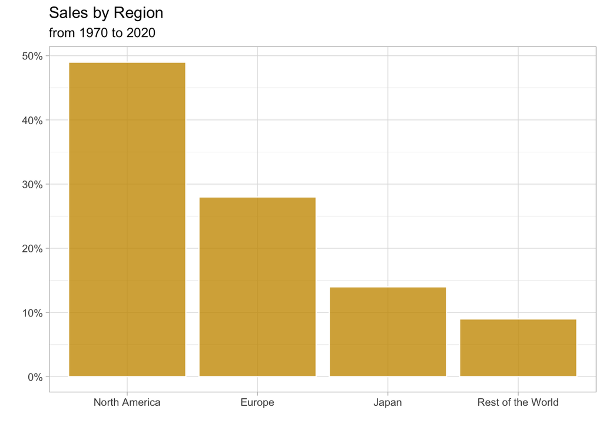

### North America

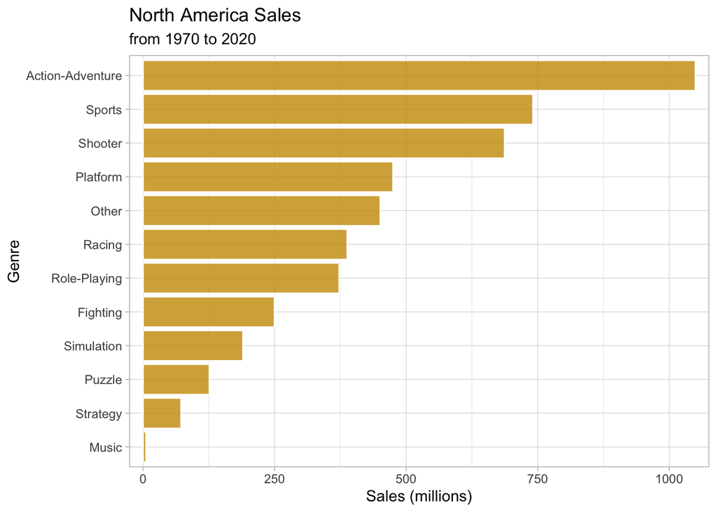

### Europe

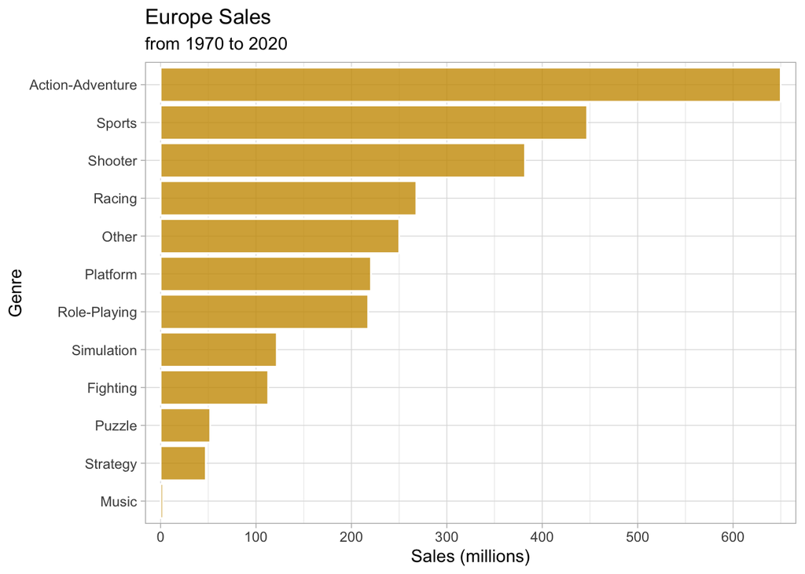

### Japan

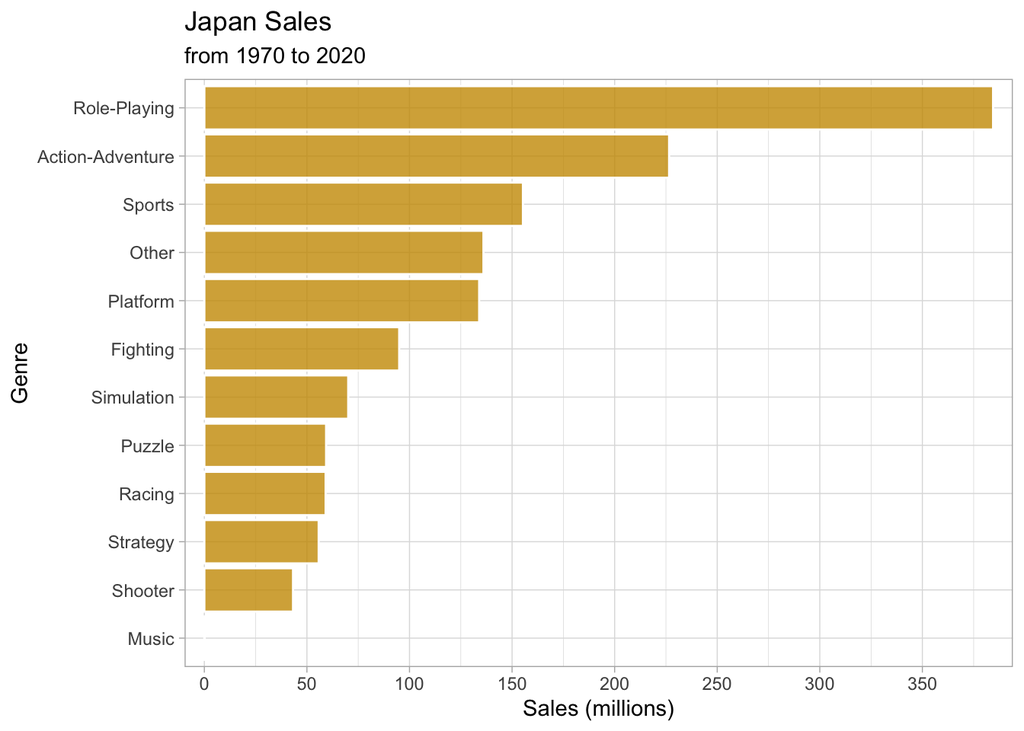

### Rest of the World

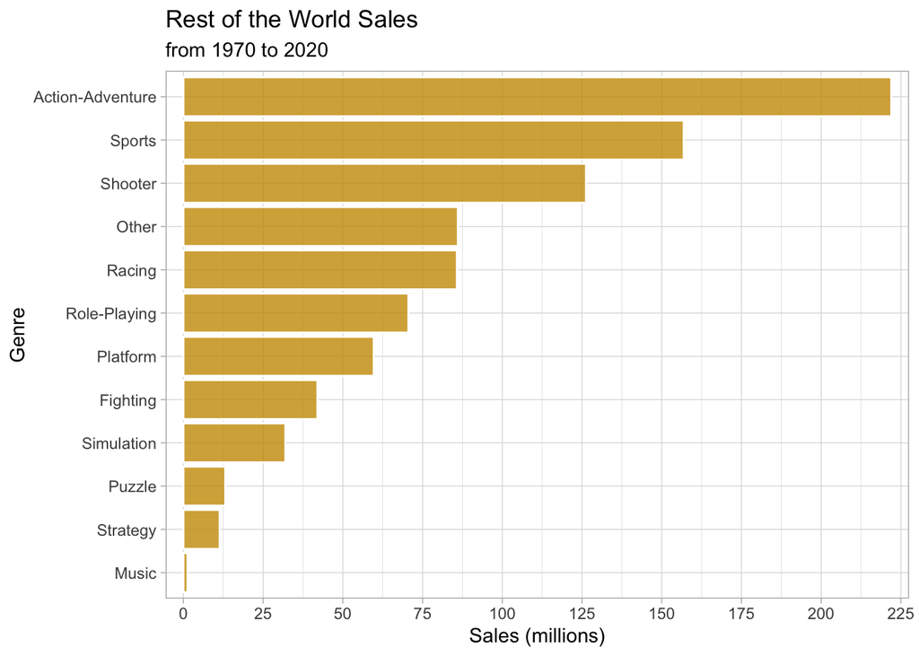

# Top Games

### Top 10 Games

| name | total_global_sales |
| --- | --- |
| Wii Sports | 82.53 |
| Grand Theft Auto V | 65.46 |
| Super Mario Bros. | 45.31 |
| Tetris | 35.84 |
| Mario Kart Wii | 35.52 |
| Minecraft | 33.19 |
| Wii Sports Resort | 32.77 |
| Pokemon Red/Pokemon Blue | 31.37 |
| Call of Duty: Black Ops | 30.99 |
| Call of Duty: Modern Warfare 3 | 30.71 |

The results are interesting; **Nintendo** taking up 60% of the top ten with the top game being Wii Sports.

### Top Genres

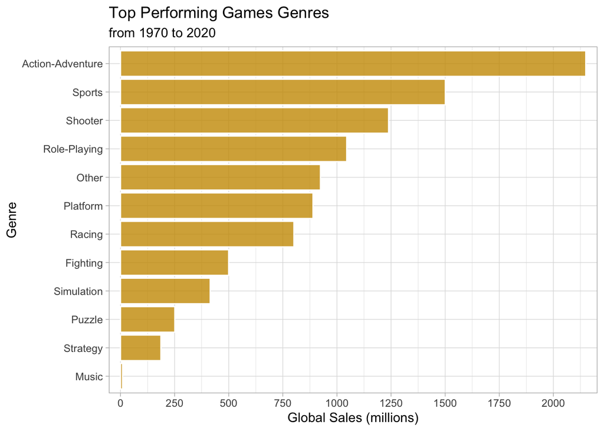

# Recommendations

Well it’s not that straight forward. The top performing games, especially the likes of Wii Sports are pretty unique and could have easily gone the other way and not been a hit at all.

I think it’s pretty safe to say that Action and Adventure games do well. Grand Theft Auto is the best example. People love it for many reasons, mostly:

1. Aesthetics - the graphics are very good and it’s great to look at.
2. Characters - you are able to choose from different protagonists, who are unique.
3. It’s also a very good multi-player game.

Sports games may be a little risky to be honest. Wii Sports is a bit of an outlier and FIFA pretty much dominates the football category.

Shooter games could be a recommendation from me. In terms of trends, sales have never gone down. I think fun, nostalgia games such as Duck Hunt or even the N64 classic Golden Eye, which is an absolute cult classic could be a suitable route. However, this should perhaps be left to Nintendo and actually producing something more in line with Call of Duty might be more appropriate.

It also depends on what market you intend to launch the game. North America and Europe are fairly similar in terms to the top performing games, however if you were to only target Japan. Action and Adventure, Sports and Shooter games would not be the best type of game as they are more into Role Playing games and in particular, Pokemon!

It’s important to learn what games sell many copies and to understand why they are popular, however I think ultimately, the most important thing for creating a new game is that it needs to be unique and creative in order to stand out.